# Hockey Match Report

Analyst’s Diary Match Report

# United States of America vs Germany

**20 May 2026**  
IIHF World Championship 2026 – Group Stage

United States of America (USA) 4:3 Germany (GER)

Report generated from the match shot-location pipeline. Metrics marked as proxies are based on OCR-extracted shot coordinates and should be interpreted as transparent spatial indicators rather than official tracking data.

Prepared by Antonin Kremenak

# Executive summary

- United States of America generated the higher official shots-on-goal volume.
- United States of America produced the stronger location-based Shot Quality Index.
- Germany got more attempts from the inner-slot / high-danger area.
- Germany led in high-danger chances based on the distance-and-lane proxy.

Shots On Goal

GER: 34 | USA: 39

Blocked Shots

GER: 11 | USA: 13

Scoring Chances

GER: 10 | USA: 18

# 1. Public layer: simple match metrics

These visuals are designed as a simple entry point for wider audiences: official shots on goal, blocked shots, shot quality proxies and basic chance creation.

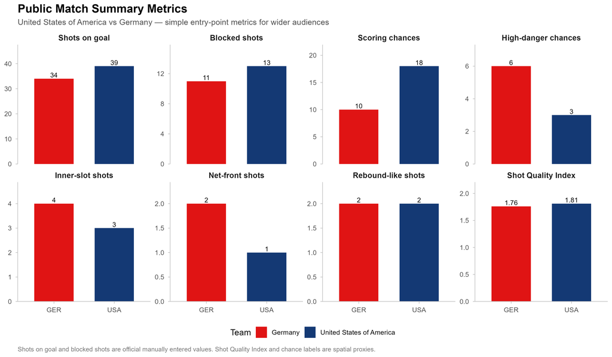

Key Metrics: United States of America vs Germany

20 May 2026 — Shot Quality Index is a location-based proxy, not a trained xG model.

| Metric | USA | GER |
| --- | --- | --- |
| OCR detected attempts | 29.00 | 30.00 |
| Corsi attempts | 29.00 | 30.00 |
| Fenwick attempts | 21.00 | 22.00 |
| Scoring chances | 18.00 | 10.00 |
| High-danger chances | 3.00 | 6.00 |
| Shot Quality Index | 1.81 | 1.76 |

# 2. Shot maps and spatial overview

Shot maps show where attempts came from, how dangerous they were spatially, and how shot locations changed across periods.

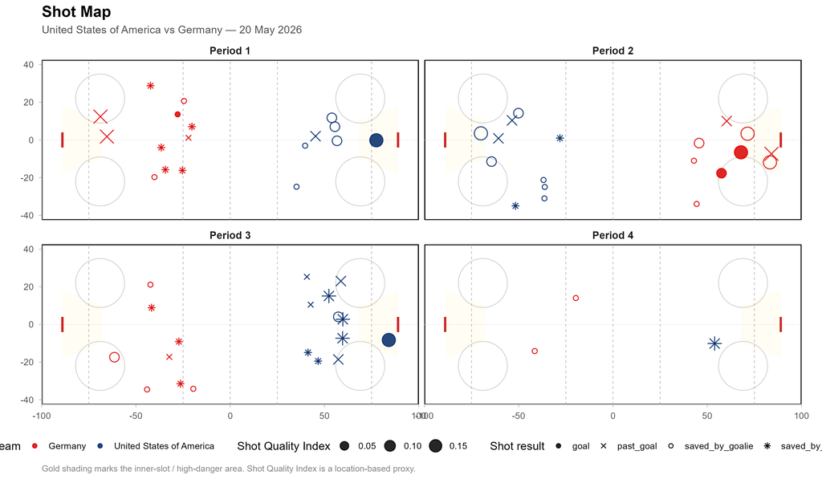

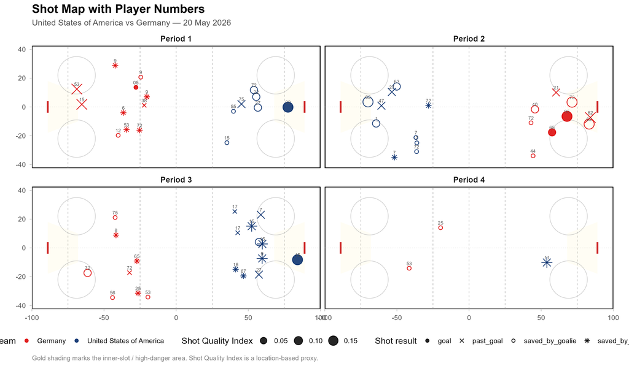

# 3. Shot quality and territorial battle

This section moves from simple shot counts to spatial pressure: location quality, offensive-zone density and period-by-period territorial advantage.

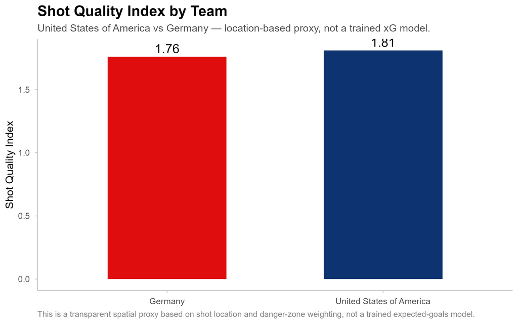

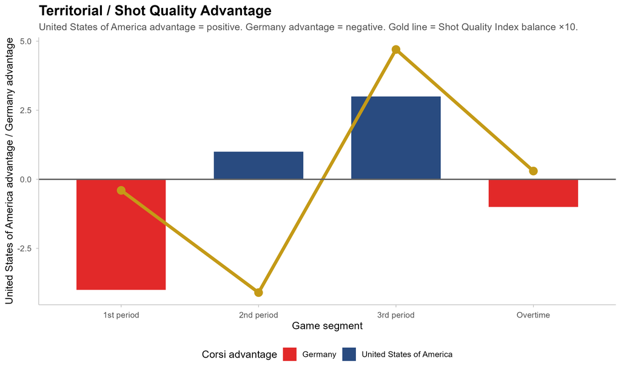

# 4. Offensive-zone density

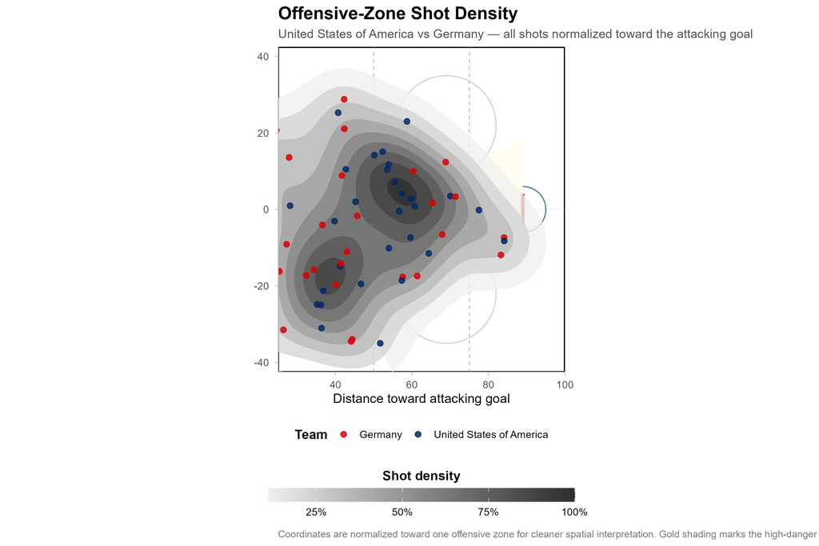

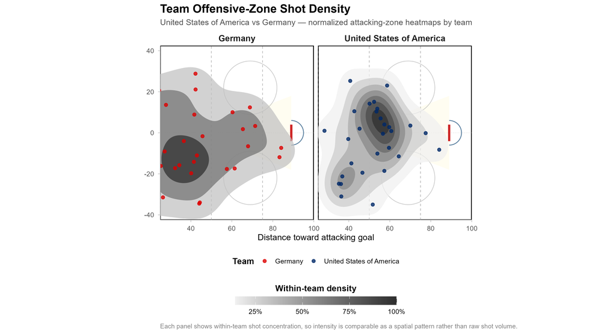

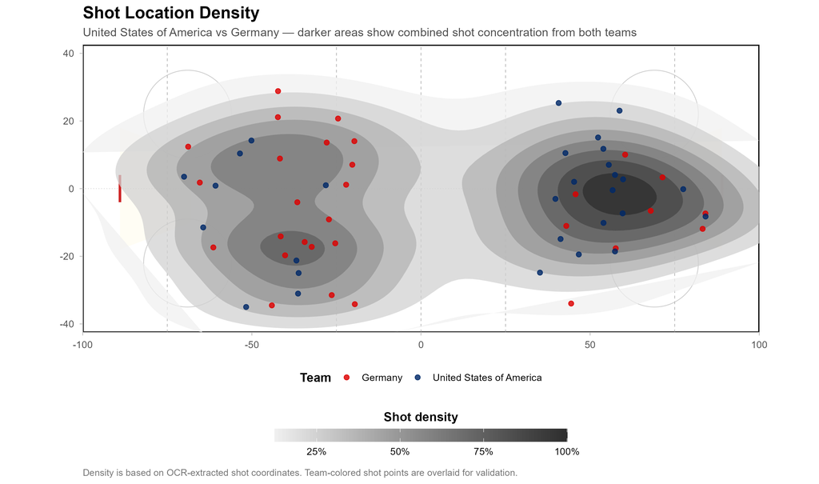

# 5. Advanced insider layer

The following metrics are proxy-based insider indicators built from the available shot-location sample. They are useful for storytelling, but they are not a substitute for full play-by-play or tracking data.

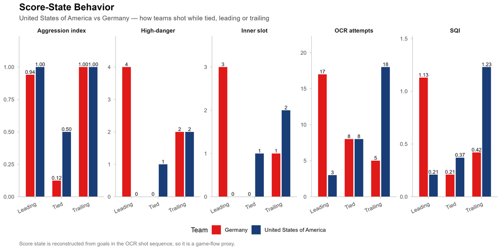

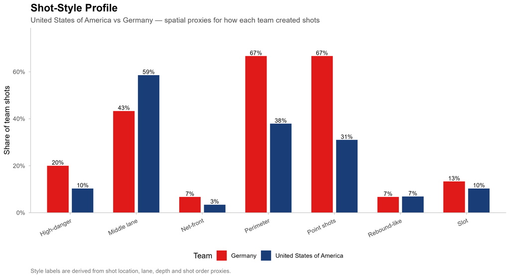

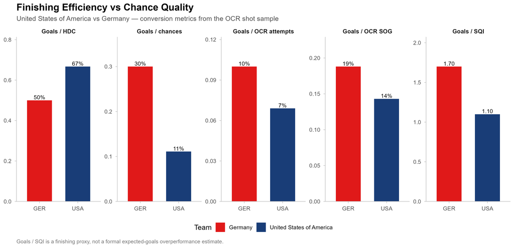

# 6. Momentum

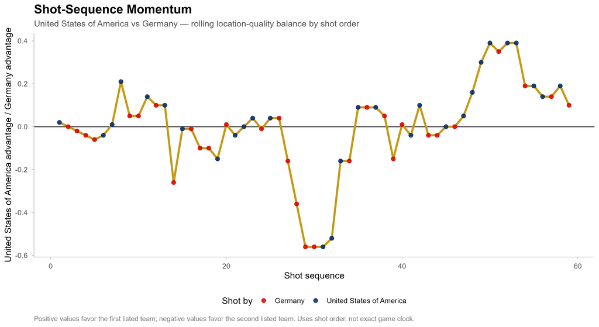

# 7. Player layer

**Player public leaders**

Top players from the OCR-extracted shot sample

| Team | Player no. | OCR attempts | OCR shots on goal | Scoring chances | High-danger chances | Inner-slot shots | Net-front shots | Rebound-like shots | Shot Quality Index | Avg shot distance |
| --- | --- | --- | --- | --- | --- | --- | --- | --- | --- | --- |
| United States of America | 15 | 5 | 3 | 4 | 1 | 1 | 1 | 1 | 0.41 | 34.0 |
| Germany | 62 | 2 | 1 | 2 | 2 | 2 | 2 | 1 | 0.36 | 11.0 |
| United States of America | 22 | 2 | 2 | 2 | 1 | 1 | 0 | 0 | 0.25 | 22.8 |
| United States of America | 63 | 2 | 2 | 2 | 1 | 1 | 0 | 0 | 0.25 | 30.3 |
| Germany | 53 | 4 | 2 | 1 | 1 | 1 | 0 | 0 | 0.24 | 51.9 |
| United States of America | 27 | 3 | 1 | 3 | 0 | 0 | 0 | 1 | 0.21 | 35.3 |
| Germany | 15 | 1 | 0 | 1 | 1 | 0 | 0 | 0 | 0.18 | 23.7 |
| Germany | 73 | 1 | 1 | 1 | 1 | 1 | 0 | 0 | 0.18 | 17.9 |
| Germany | 95 | 1 | 1 | 1 | 1 | 0 | 0 | 1 | 0.18 | 22.1 |
| Germany | 72 | 4 | 2 | 1 | 0 | 0 | 0 | 0 | 0.13 | 51.2 |
| United States of America | 7 | 4 | 2 | 1 | 0 | 0 | 0 | 0 | 0.13 | 51.0 |
| United States of America | 72 | 3 | 2 | 1 | 0 | 0 | 0 | 0 | 0.11 | 53.0 |

*Player-level statistics are generated from OCR-detected shot markers and spatial coordinates from IIHF shot charts. Due to OCR limitations and embedded IIHF PDF fonts, some player-level counts may contain minor inaccuracies.*

[output not shown]